# Case Study 1

Ariel Francisco

March 25, 2017

## Introduction

In this study, we analyze the gross domestic product of 189 countries. The data is obtained from online data files, tidied, then merged. The merged data is then used to provide comparisons between the countries.

The study focuses on 5 different income groups based on GDP. The groups are High Income: OECD, High Income: Non-OECD, Upper Middle Income, Lower Middle Income, and Lower Income.

The data can be found in the links below. Load the Gross Domestic Product data for the 190 ranked countries in this data set: https://d396qusza40orc.cloudfront.net/getdata%2Fdata%2FGDP.csv Load the educational data from this data set: https://d396qusza40orc.cloudfront.net/getdata%2Fdata%2FEDSTATS_Country.csv

## Importing, Tidying, and Merging the Data

### Loading the packages used in the code and Setting the Working Drive

```r
library(dplyr)
```

```r
library(repmis)
library(ggplot2)
library(scales)
setwd("C:/Users/Ariel/Desktop/01 DATA SCIENCE/DDS/DATA File")
```

### Importing the data files

The files are being downloaded from the website and being stored as

1. stas.data
2. gdp.data

```r
# read in csv file "getdata_data_EDSTATS_Country" from website and save to working drive
site1 <- "https://d396qusza40orc.cloudfront.net/getdata%2Fdata%2FEDSTATS_Country.csv"
download.file(site1, destfile="getdata_data_EDSTATS_Country.csv")

#read in csv file "getdata_data_GDP" from website and save to working drive
site2 <- "https://d396qusza40orc.cloudfront.net/getdata%2Fdata%2FGDP.csv"
download.file(site2, destfile="getdata_data_GDP.csv")

#read in csv file "getdata_data_EDSTATS_Country"
stats.data <- read.csv("getdata_data_EDSTATS_Country.csv")

#read in csv file "getdata_data_GDP" skipping the first three rows
gdp.data <- read.csv("getdata_data_GDP.csv", skip=3, header=TRUE)
```

### Tyding the data

```r
##Tidying stats.data file
#deleting the columns in stats.data that are not used in the analysis
stats.data <- stats.data[-c(2,4:31)]
print("Number of missing values in the Income Group column of getdata_data_EDSTATS_Country data file")
```

```
## [1] "Number of missing values in the Income Group column of getdata_data_EDSTATS_Country data file"
```

```r
#number of missing values in the Income Group column of stats.data
sum(stats.data$Income.Group=="")
```

```
## [1] 24
```

```r
#deleting the rows with missing values in then Income Group
stats.data <- stats.data[!(stats.data$Income.Group==""),]


##Tidying gdp.data file
#deleting columns in gdp.data not used in the analysis
gdp.data <- gdp.data[-c(3,6:10)]
#deleting blank rows not used in the analysis
gdp.data <- gdp.data[-c(1, 192:327), ]
#renaming the column headers in gdp.data
gdp.data <- rename(gdp.data, CountryCode = X, Country = Economy, GDP.in.Millions.USD = US.dollars.)
#convering Ranking column from factor to numeric
gdp.data$Ranking <- as.numeric(as.character(gdp.data$Ranking))
#removing the commas in the GDP.in.Millions.USD column
gdp.data$GDP.in.Millions.USD <- gsub(",", "", gdp.data$GDP.in.Millions.USD)
#convering GDP.in.Millions.USD column from character to numeric
gdp.data$GDP.in.Millions.USD <- as.numeric(as.character(gdp.data$GDP.in.Millions.USD))
```

### Merging the data

```r
#merging stats.data and gdp.data by CountryCode column
gdp.stats.merged = merge(stats.data, gdp.data, by="CountryCode")
```

## Analyzing the merged data

#### 1) Number of country codes that matched after merging the tidyed data files.

```r
#Number of country codes that matched both data files
length(gdp.stats.merged$CountryCode)
```

```
## [1] 189
```

189 countries codes matched from the files stats.data and gdp.data after both files were tidyed. The raw data contained more country codes were removed during tidying due to the lack of info for the country.

#### 2) Sorting the data in ascending order by GDP. We can see the 13th country.

```r
#sorting gdp.stats.merged in ascending order by GDP
gdp.stats.merged <- gdp.stats.merged[order(gdp.stats.merged$GDP.in.Millions.USD),]

#What is the 13th Country by GDP ranked lowest to highest?
gdp.stats.merged[13,]
```

```
##    CountryCode        Income.Group Ranking             Country
## 93         KNA Upper middle income     178 St. Kitts and Nevis
##    GDP.in.Millions.USD
## 93                 767
```

#### We can see that St. Kitts and Nevis is the 13th, however, it is tied with Grenada. You can see that below by listing the first 13 countries by GDP.

```r
#listing first 13 countries in ascending GDP order
gdp.stats.merged[1:13,]
```

```
##     CountryCode        Income.Group Ranking                        Country
## 173         TUV Lower middle income     190                         Tuvalu
## 92          KIR Lower middle income     189                       Kiribati
## 113         MHL Lower middle income     188               Marshall Islands
## 137         PLW Upper middle income     187                          Palau
## 155         STP Lower middle income     186          São Tomé and Principe
## 59          FSM Lower middle income     185          Micronesia, Fed. Sts.
## 169         TON Lower middle income     184                          Tonga
## 46          DMA Upper middle income     183                       Dominica
## 39          COM          Low income     182                        Comoros
## 184         WSM Lower middle income     181                          Samoa
## 180         VCT Upper middle income     180 St. Vincent and the Grenadines
## 69          GRD Upper middle income     178                        Grenada
## 93          KNA Upper middle income     178            St. Kitts and Nevis
##     GDP.in.Millions.USD
## 173                  40
## 92                  175
## 113                 182
## 137                 228
## 155                 263
## 59                  326
## 169                 472
## 46                  480
## 39                  596
## 184                 684
## 180                 713
## 69                  767
## 93                  767
```

#### 3) The average GDP rankings for the “High income: OECD” and “High income:nonOECD” groups are

```r
#grouping gdp.stats.merged into groups by Income.Group
by_Income.Group <- group_by(gdp.stats.merged, Income.Group)
#obtaining the average GDP ranking of each group
summary<- summarise(by_Income.Group,mean = mean(Ranking))
summary[1:2,]
```

```
## # A tibble: 2 × 2
##           Income.Group     mean
##                 <fctr>    <dbl>
## 1 High income: nonOECD 91.91304
## 2    High income: OECD 32.96667
```

The average GDP ranking for High Income: nonOECD is 91.91304 The average GDP ranking for High Income: OECD is 32.96667

#### 4) Graph of distribution of GDP value for all the countries and color plots by income group

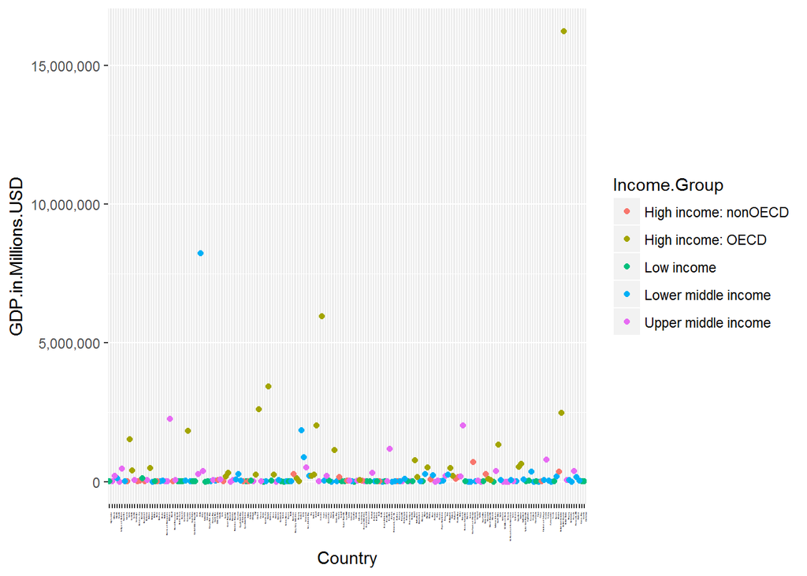

```r
#setup ggplot with data frame gdp.stats.merged
g <- ggplot(gdp.stats.merged, aes(Country, GDP.in.Millions.USD))
#adding color by Income.Group + converting from scientific notation to commas + listing the country names vertically on x-axis + decreasing font size on x-axis
g + geom_point(aes(color = Income.Group)) + scale_y_continuous(labels = comma) + theme(axis.text.x = element_text(angle = 90, size=1, hjust=1))
```

#### 5) Summary statistics of GDP by income groups

```r
#summary statistics for GDP by income groups
summarise(by_Income.Group,mean = mean(GDP.in.Millions.USD), standard.dev = sd(GDP.in.Millions.USD),
          variance=var(GDP.in.Millions.USD), min=min(GDP.in.Millions.USD), max=max(GDP.in.Millions.USD))
```

```
## # A tibble: 5 × 6
##           Income.Group       mean standard.dev     variance   min      max
##                 <fctr>      <dbl>        <dbl>        <dbl> <dbl>    <dbl>
## 1 High income: nonOECD  104349.83    165334.45 2.733548e+10  2584   711050
## 2    High income: OECD 1483917.13   3070463.52 9.427746e+12 13579 16244600
## 3           Low income   14410.78     20473.09 4.191474e+08   596   116355
## 4  Lower middle income  256663.48   1139619.92 1.298734e+12    40  8227103
## 5  Upper middle income  231847.84    476872.04 2.274069e+11   228  2252664
```

```r
summarise(by_Income.Group, median=median(GDP.in.Millions.USD))
```

```
## # A tibble: 5 × 2
##           Income.Group   median
##                 <fctr>    <dbl>
## 1 High income: nonOECD  28373.0
## 2    High income: OECD 486528.5
## 3           Low income   7843.0
## 4  Lower middle income  24272.0
## 5  Upper middle income  42945.0
```

In the two tables above you can see the mean, standard deviation, variance, minimum, maximum, and median for the 5 income groups.

#### 6) GDP rankings are cut into 5 quartiles and compared on the table below with the income groups.The countries that are Lower middle income but among the 38 nations with highest GDP are provided below the table.

```r
#cutting Ranking into 5 quantile groups
Quantile <- cut(gdp.stats.merged$Ranking, breaks=5,labels = FALSE, include.lowest = TRUE, right = FALSE)
#creating new object with a new column, Quantile
quantile.gdp.stats.merged <- mutate(gdp.stats.merged, Quantile)
#converting Quantile from integer to numeric
quantile.gdp.stats.merged$Quantile <- as.numeric(as.integer(quantile.gdp.stats.merged$Quantile))
#making a table Quantile vs. Income.Group
table<- table(quantile.gdp.stats.merged$Quantile, quantile.gdp.stats.merged$Income.Group)
#countries that are Lower middle income but among the 38 nations with highest GDP
table
```

```
##
##        High income: nonOECD High income: OECD Low income
##   1  0                    4                18          0
##   2  0                    5                10          1
##   3  0                    8                 1          9
##   4  0                    4                 1         16
##   5  0                    2                 0         11
##
##     Lower middle income Upper middle income
##   1                   5                  11
##   2                  13                   9
##   3                  12                   8
##   4                   8                   8
##   5                  16                   9
```

```r
table[1,5]
```

```
## [1] 5
```

There are 5 countries in the Lower middle income group that are also in the highest GDP quantile.

## Conclusion

Through the analysis of the GDP data, we can compare the countries by GDP and by their income groups. As can be expected, the High Income groups contained most of the world’s wealth, measured by GDP. An interesting point that may not have been expected, is that some countries are in the lower income groups, however, their GDP rank is near the top of the list.